# **RQDA: un paquete de análisis cualitativo para R**

Mario Domínguez

# **Algunos Antecedentes**

## Revisión histórica

RDQA es un paquete de R para el Análisis de Datos Cualitativos, (licencia BSD) gratuita creado por Huang Ronggui, sociólogo de la Fundan University en Shangai, China. Funciona en plataformas Windows, Linux / FreeBSD y Mac OSX.

RQDA es una herramienta fácil de usar para ayudar en el análisis de datos textuales, por el momento sólo admite datos de texto en formato “.txt”.

- Toda la información se almacena en una base de datos SQLite a través del paquete R de RSQLite.
- La Interfaz Gráfica de Usuario (GUI) se basa en RGtk2, a través de la ayuda de gWidgetsRGtk2. Incluye una serie de características estándar de análisis de datos cualitativos asistidos por computadora.
- Actualmente tiene algunos problemas de compàtibilidad con Mac OSX, pero existen soluciones alternativas que permiten su ejecución. [esta solución me resultó a mi en OSX (http://marcoghislanzoni.com/blog/2014/08/29/solved-installing-rattle-r-3-1-mac-os-x-10-9/)]

# **Usos**

- RQDA permite el análisis de distinto tipo, su flexibilida permite la construcción de categorías emergentes como también la posibilidad de establecer categorías y “vaciar” información en ellas.
- el vínculo con R permite transformar los resultados en marcos de datos analizables: frecuencias, nubes de palabras.
- Con Shiny, un paquete de R que permite realizar reportes interactivo se han desarrollado buenas soluciones para filtrar y descargar las codificaciones realizada Por ejemplo:el paquete RQDAPlus. (en eso nuestr-s amig-s de la comunidad R pueden aportar muchisimo en mejorar)

# ¿Que posibilidades de análisis entrega RQDA?

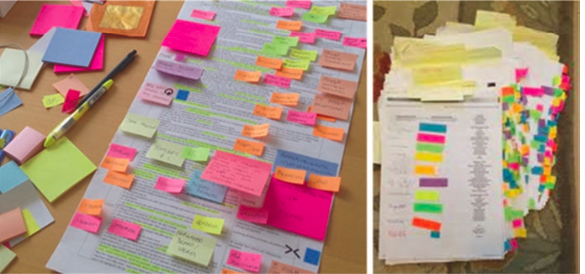

## **Tipos de registros**

- Registro y elaboración ordenada de archivos
- Códigos únicos y múltiples para cada texto seleccionado
- Categorías que agrupan códigos.
- Memos y diarios que permiten el registro permanente de cada desición metodológica o conceptualización teórica.
- Registro de Casos y Atributos de l-s entrevistad-s.
- Trabajo por medio de la lógica de proyectos, lo que facilita la organización de diversos estudios.

# **La GUI de RQDA**

[figure not shown]

## no es la gran cosa…

[figure not shown]

# **Reflexiones sobre su uso**

- A diferencia de otros softwares cualitativos RQDA permite un tratamiento de datos susceptible de ser integrada a otros tipos de análisis.
- Fomenta la transformación digital de los y las investigadoras aportando al emergente campo de las “humanidades digitales”
- Aporta soluciones prácticas a los debates epistemoógicos en torno a la “rivalidad” cuali/cuanti.
- Debido a su permanente desarrollo tiene varios problemas de compatibilidad, pero gracias a la coomunidad de R pueden resolverse.

# **Algunos link de interés…**

[https://rpubs.com/dastan/rqda_english] [https://lucidmanager.org/discourse-network-analysis-literature-review/] [https://www.youtube.com/user/RQDAtuto]